# Missing Longitudinal Data

## SHARE-Child Pakistan

First, let’s read our data into R again.

```r
library(haven)
dep=read_dta("~/Documents/TEACHING/SHARE-Child data/SC_anonymized_forAmy_20180314.dta")

#PHQ>9 a sign of potential moderate to severe depression
dep$depressed=dep$phqTotal>9; dep$y=as.numeric(dep$depressed)
dep$edu=cut(dep$momEduc,breaks=c(-.001,12,16))
dep$age=cut(dep$momAge,breaks=c(15,30,41))
dep$pid=dep$anon_id
dep$time=as.factor(dep$timepoint)
depfinal=dep[,c(8,9:12)] #pick off ID, time, outcome, edu, and age
```

## Missing data in SHARE-Child

In SHARE-Child Pakistan, we have missing data on the depression outcome measured longitudinally. Our data are structured so that we have one line per person for each measurement occasion.

```r
head(depfinal)
```

```
## # A tibble: 6 x 5
##       y edu         age       pid time
##   <dbl> <fct>       <fct>   <dbl> <fct>
## 1     0 (-0.001,12] (15,30]     1 0
## 2     0 (-0.001,12] (15,30]     1 1
## 3     0 (-0.001,12] (15,30]     1 2
## 4     1 (-0.001,12] (15,30]     2 0
## 5     0 (-0.001,12] (15,30]     2 1
## 6     1 (-0.001,12] (15,30]     2 2
```

The variable `pid` indicates the observations from each participant.

## Missing data in SHARE-Child

To use MICE, we want to have the data structured so that we have only one line per person. Because education and age do not change within subject in these data, it is fairly straightforward to reshape the data into one line per person format.

```r
library(tidyr)
depwide2=spread(depfinal,time,y)
```

## Examine patterns of missingness

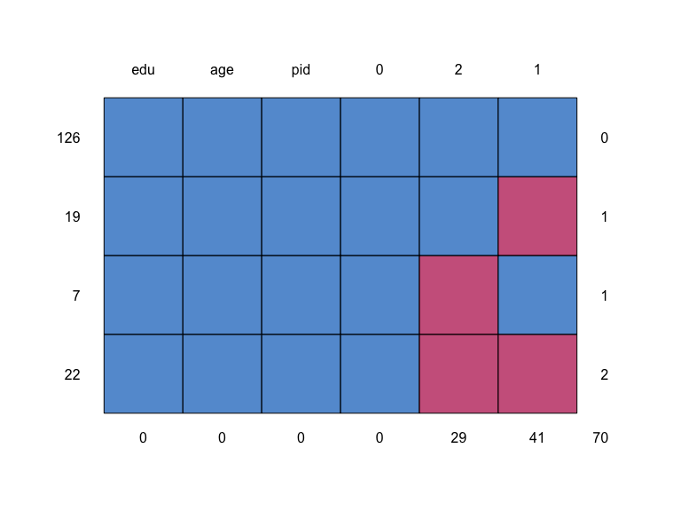

```
##     edu age pid 0  2  1
## 126   1   1   1 1  1  1  0
## 19    1   1   1 1  1  0  1
## 7     1   1   1 1  0  1  1
## 22    1   1   1 1  0  0  2
##       0   0   0 0 29 41 70
```

```r
md.pattern(depwide2)
```

Here we see that there are 126 people with no missing data, 19 who are missing the 3 month follow-up only, 7 who are only missing the 6 month follow-up, and 22 who are missing both post-baseline measurements.

## Examine missing data mechanism

```r
#depwide =1 if only missing y.1, 2 if only missing y.2, 3 if missing both
depwide2$pattern=as.numeric(is.na(depwide2$`1`))+2*as.numeric(is.na(depwide2$`2`))
```

## Predictors of missing data pattern

To look at predictors of the patterns of missing data, we can fit a multinomial logistic regression model to examine predictors of missingness of each pattern (relative to having complete data).

```r
library(nnet)
genl=multinom(pattern~age+edu+`0`,data=depwide2)
```

## Predictors of missing data pattern

```r
summary(genl)
```

```
## Call:
## multinom(formula = pattern ~ age + edu + `0`, data = depwide2)
##
## Coefficients:
##   (Intercept)  age(30,41]  edu(12,16]        `0`
## 1   -2.150815 -0.34978759   0.3270265  0.5326544
## 2   -3.092709  0.55694120 -11.1688829  0.4078089
## 3   -1.798004  0.06510159   0.9183336 -0.3385712
##
## Std. Errors:
##   (Intercept) age(30,41]  edu(12,16]       `0`
## 1   0.3999866  0.6751067   0.6922712 0.4997496
## 2   0.6257071  0.8753350 255.8445676 0.7907378
## 3   0.3405420  0.5716863   0.5571427 0.4830832
##
## Residual Deviance: 293.6323
## AIC: 317.6323
```

```r
summary(genl)$coefficients/summary(genl)$standard.errors
```

```
##   (Intercept) age(30,41]  edu(12,16]        `0`
## 1   -5.377217 -0.5181219  0.47239647  1.0658425
## 2   -4.942743  0.6362606 -0.04365495  0.5157321
## 3   -5.279829  0.1138764  1.64829151 -0.7008549
```

## Predictors of missing data pattern

That multinomial logistic regression model does not reveal strong predictors of missingness. While it is not possible to rule out MNAR, we do not see strong evidence of any observed variables (including baseline depression) predicting missingness.

## Imputation of the missing outcomes

```r
#mice did not like old names
names(depwide2)=c("edu","age","pid","y.0","y.1","y.2","pattern")
depimp <- mice(depwide2, m=20, printFlag=FALSE, maxit = 40, seed=2525)
# The output depimp contains m=20 completed datasets
```

## Looking at Imputed Values

This shows the 20 imputed values of y.1 for each observation with missing data.

```r
depimp$imp$y.1
```

```
##     1 2 3 4 5 6 7 8 9 10 11 12 13 14 15 16 17 18 19 20
## 3   1 1 1 0 0 1 1 1 1  1  0  1  0  0  0  0  0  1  1  0
## 6   0 1 1 0 0 1 0 0 0  0  1  0  1  0  0  0  1  0  0  0
## 8   1 1 1 1 0 1 1 1 0  1  1  1  1  1  0  1  0  0  0  0
## 15  1 1 1 0 0 0 1 1 1  1  1  1  1  1  1  0  0  1  0  1
## 16  0 0 0 0 0 0 0 0 0  0  1  0  1  0  0  0  0  0  0  0
## 19  0 0 0 0 0 0 1 0 0  0  0  0  0  0  0  0  0  0  0  0
## 22  1 1 1 1 0 1 0 1 1  1  1  1  0  1  0  1  1  1  1  0
## 25  0 0 0 0 1 0 0 1 0  0  0  1  1  0  0  0  1  0  0  0
## 27  0 0 0 1 0 1 0 0 0  0  0  1  0  0  1  0  0  0  1  0
## 28  0 0 0 1 0 1 1 1 0  1  1  1  1  1  1  1  1  1  0  0
## 36  1 0 0 0 0 0 1 0 1  1  1  1  0  1  0  1  1  0  1  1
## 39  0 1 1 0 1 0 0 1 0  1  1  0  1  1  1  1  1  1  0  1
## 40  1 1 0 0 0 1 0 1 0  1  0  0  1  1  1  0  0  1  1  1
## 41  0 1 1 1 0 0 0 1 0  1  0  1  0  1  0  0  1  1  1  1
```

[output cut: 27 more lines]

## Reshaping data

In order to fit a GEE to these data, we need to transform the data structure back into “long” format from “wide” format. We can do this reconfiguration as follows.

```r
depimp.data=as.list(1:20)
for (i in 1:20) {
  depimp.data[[i]]=mice::complete(depimp,action=i)
}
# transpose data and add time variable back
depimp.data2 <- lapply(depimp.data,reshape,varying=4:6,v.names="dep",idvar="pid",
                       timevar="followup",times=c(0,1,2),direction="long")
depimp.data2 <- lapply(depimp.data2,FUN=function(u){ u[order(u$pid),]})
```

## Fit GEE to each imputed dataset

```r
library(geepack)
depimp.gee=lapply(depimp.data2,
                  FUN=function(u){geeglm(dep~as.factor(followup)+edu,
                                         id=as.factor(pid), family=binomial(),
                                corstr="exchangeable",waves=followup,data=u)})
```

## Look at each analysis

```r
depimp.gee
```

```
## [[1]]
##
## Call:
## geeglm(formula = dep ~ as.factor(followup) + edu, family = binomial(),
##     data = u, id = as.factor(pid), waves = followup, corstr = "exchangeable")
##
## Coefficients:
##          (Intercept) as.factor(followup)1 as.factor(followup)2
##           -0.1844188           -0.6920150           -1.4910757
##           edu(12,16]
##            0.1606520
##
## Degrees of Freedom: 522 Total (i.e. Null);  518 Residual
##
## Scale Link:                   identity
## Estimated Scale Parameters:  [1] 1.000695
##
## Correlation:  Structure = exchangeable    Link = identity
## Estimated Correlation Parameters:
##    alpha
## 0.106997
##
## Number of clusters:   174   Maximum cluster size: 3
##
##
## [[2]]
##
## Call:
## geeglm(formula = dep ~ as.factor(followup) + edu, family = binomial(),
##     data = u, id = as.factor(pid), waves = followup, corstr = "exchangeable")
##
## Coefficients:
##          (Intercept) as.factor(followup)1 as.factor(followup)2
##           -0.2011790           -0.6119469           -1.2936825
##           edu(12,16]
##            0.2792570
##
## Degrees of Freedom: 522 Total (i.e. Null);  518 Residual
##
## Scale Link:                   identity
```

[output cut: 443 more lines]

```
##           -0.1377222           -0.8044200           -1.2918676
##           edu(12,16]
##           -0.1648546
##
## Degrees of Freedom: 522 Total (i.e. Null);  518 Residual
##
## Scale Link:                   identity
## Estimated Scale Parameters:  [1] 0.999538
##
## Correlation:  Structure = exchangeable    Link = identity
## Estimated Correlation Parameters:
##    alpha
## 0.138856
##
## Number of clusters:   174   Maximum cluster size: 3
```

## Grab estimates and SE’s to use Rubin’s rules

```r
depimp.parms <- lapply(depimp.gee,coefficients)
depimp.ses <- lapply(depimp.gee,FUN=function(u){
    sqrt(diag(u$geese$vbeta))
})
```

## Pooling using Rubin’s rules

For this GEE, we cannot use MICE for the pooling, but we can use the mi.inference function from the `norm` package.

```r
library(norm)
mi.parms = mi.inference(depimp.parms,depimp.ses,confidence=0.95)
mi.results = cbind(mi.parms$est,mi.parms$std.err,mi.parms$lower,mi.parms$upper, mi.parms$df)
colnames(mi.results) <- c("Est","StdErr","Lower","Upper","DF")
exp.mi.results=data.frame(cbind(exp(mi.parms$est),exp(mi.parms$lower),exp(mi.parms$upper)))

names(exp.mi.results)=c("estimate","lower 95% CL","upper 95% CL")
```

## Interpretation

You practice! Interpret the results from this GEE using MI. Do our answers mirror those in the complete case analysis?

```r
mi.results
```

```
##                              Est    StdErr      Lower      Upper
## (Intercept)          -0.15630784 0.1636025 -0.4769779  0.1643622
## as.factor(followup)1 -0.82358762 0.2549779 -1.3250962 -0.3220790
## as.factor(followup)2 -1.26686364 0.3312981 -1.9272123 -0.6065150
## edu(12,16]           -0.03476788 0.3257863 -0.6779599  0.6084242
##                              DF
## (Intercept)          25894.1879
## as.factor(followup)1   344.6380
## as.factor(followup)2    72.5272
## edu(12,16]             166.9425
```

```r
exp.mi.results
```

```
##                       estimate lower 95% CL upper 95% CL
## (Intercept)          0.8552959    0.6206563    1.1786411
## as.factor(followup)1 0.4388544    0.2657774    0.7246409
## as.factor(followup)2 0.2817138    0.1455534    0.5452478
## edu(12,16]           0.9658296    0.5076516    1.8375335
```